# Spring 2019 Learning envt SI NN

Donna McDermott

April 22, 2019

This data was collected in April of 2019 as a follow up on last summer’s social information experiment. In this experiment as in the last one, bees were tasked with foraging on two flowers over two days. On day one, their flower choices were blue (rewarding) or green (water). On day two, the same bees were placed in the same enclosures to forage on either blue (still the samelevel of reward) or purple (equally rewarding) flowers. Again, bees were assigned to different treatments with different social information cues on day one: honest (model bee on blue flower), misleading (model bee on green flower), or control (no model bee.) However, the change from my last experiments is that, this time, bees were in one of two treatments for 3 days preceding the trial: neonic-exposed and not neonic exposed. Neonic exposure (10 ppb) was through their ad. lib. supply of 1 M nectar. Bees were taken from one of two different colonies. Both day 1 and day 2 foraging bouts lasted for 30 minutes, bees were tested independently, and 7 or 8 trials ran simulateously in the chamber at one time. In the colony (before testing) all bees were fed ad lib Koppert nectar solution and commercial pollen. Bees were starved for a minimim of two hours before entering foraging chamber.

Data from the 2 colonies we recieved on 2/5/19 (which were tested in the foraging chamber in March) are not included in this analysis. This is because those colonies died ~3 weeks into the experiment, with considerable decline beforehand. In early/mid march, the queens in both colonies stopped laying eggs. Soon afterwards, most bees stopped foraging when in the foraging chamber. Laura Avila and I have talked a lot about what might have happened to these colonies. I think it’s most likely that the bees came in with some sort of pathogen, which spread to the other colony. We cleaned every surface we could think of with bleach before setting up the colonies we received on 3/26/19. So far, these 3/26 colonies don’t exhibit the same failure to thrive.

```r
#importing and naming each data set

#Treatments
Tr.1416=read.csv("foragingdata_2019.4.1.1416.csv")
colnames(Tr.1416) = c("date", "t.day", "flower", "bee", "t.forage", "reward")

Tr.1506=read.csv("foragingdata_2019.4.1.1506.csv")
colnames(Tr.1506) = c("date", "t.day", "flower", "bee", "t.forage", "reward")

Tr.1557=read.csv("foragingdata_2019.4.1.1557.csv")
colnames(Tr.1557) = c("date", "t.day", "flower", "bee", "t.forage", "reward")

Tr.1636=read.csv("foragingdata_2019.4.1.1636.csv")
colnames(Tr.1636) = c("date", "t.day", "flower", "bee", "t.forage", "reward")

Tr.1141=read.csv("foragingdata_2019.4.11.1141.csv")
colnames(Tr.1141) = c("date", "t.day", "flower", "bee", "t.forage", "reward")

Tr.1240=read.csv("foragingdata_2019.4.11.1240.csv")
colnames(Tr.1240) = c("date", "t.day", "flower", "bee", "t.forage", "reward")

Tr.1340=read.csv("foragingdata_2019.4.11.1340.csv")
colnames(Tr.1340) = c("date", "t.day", "flower", "bee", "t.forage", "reward")

Tr.1327=read.csv("foragingdata_2019.4.15.1327.csv")
colnames(Tr.1327) = c("date", "t.day", "flower", "bee", "t.forage", "reward")

Tr.1408=read.csv("foragingdata_2019.4.15.1408.csv")
colnames(Tr.1408) = c("date", "t.day", "flower", "bee", "t.forage", "reward")

Tr.1447=read.csv("foragingdata_2019.4.15.1447.csv")
colnames(Tr.1447) = c("date", "t.day", "flower", "bee", "t.forage", "reward")

Tr.1538=read.csv("foragingdata_2019.4.15.1538.csv")
colnames(Tr.1538) = c("date", "t.day", "flower", "bee", "t.forage", "reward")

Tr.1623=read.csv("foragingdata_2019.4.15.1623.csv")
colnames(Tr.1623) = c("date", "t.day", "flower", "bee", "t.forage", "reward")

Tr.1324=read.csv("foragingdata_2019.4.18.1324.csv")
colnames(Tr.1324) = c("date", "t.day", "flower", "bee", "t.forage", "reward")

Tr.1404=read.csv("foragingdata_2019.4.18.1404.csv")
colnames(Tr.1404) = c("date", "t.day", "flower", "bee", "t.forage", "reward")

Tr.1450=read.csv("foragingdata_2019.4.18.1450.csv")
colnames(Tr.1450) = c("date", "t.day", "flower", "bee", "t.forage", "reward")

Tr.1538=read.csv("foragingdata_2019.4.18.1538.csv")
colnames(Tr.1538) = c("date", "t.day", "flower", "bee", "t.forage", "reward")

Tr.1402=read.csv("foragingdata_2019.4.23.1402.csv")
colnames(Tr.1402) = c("date", "t.day", "flower", "bee", "t.forage", "reward")
Tr.1453=read.csv("foragingdata_2019.4.23.1453.csv")
colnames(Tr.1453) = c("date", "t.day", "flower", "bee", "t.forage", "reward")
Tr.1535=read.csv("foragingdata_2019.4.23.1535.csv")
colnames(Tr.1535) = c("date", "t.day", "flower", "bee", "t.forage", "reward")
Tr.1622=read.csv("foragingdata_2019.4.23.1622.csv")
colnames(Tr.1622) = c("date", "t.day", "flower", "bee", "t.forage", "reward")
Tr.1708=read.csv("foragingdata_2019.4.23.1708.csv")
colnames(Tr.1708) = c("date", "t.day", "flower", "bee", "t.forage", "reward")

#Tests
Te.1404=read.csv("foragingdata_2019.4.2.1404.csv")
colnames(Te.1404) = c("date", "t.day", "flower", "bee", "t.forage", "reward")

Te.1455=read.csv("foragingdata_2019.4.2.1455.csv")
colnames(Te.1455) = c("date", "t.day", "flower", "bee", "t.forage", "reward")

Te.1544=read.csv("foragingdata_2019.4.2.1544.csv")
colnames(Te.1544) = c("date", "t.day", "flower", "bee", "t.forage", "reward")

Te.1644=read.csv("foragingdata_2019.4.2.1644.csv")
colnames(Te.1644) = c("date", "t.day", "flower", "bee", "t.forage", "reward")

Te.1247=read.csv("foragingdata_2019.4.12.1247.csv")
colnames(Te.1247) = c("date", "t.day", "flower", "bee", "t.forage", "reward")

Te.1350=read.csv("foragingdata_2019.4.12.1350.csv")
colnames(Te.1350) = c("date", "t.day", "flower", "bee", "t.forage", "reward")

Te.1432=read.csv("foragingdata_2019.4.12.1432.csv")
colnames(Te.1432) = c("date", "t.day", "flower", "bee", "t.forage", "reward")

Te.1430=read.csv("foragingdata_2019.4.16.1430.csv")
colnames(Te.1430) = c("date", "t.day", "flower", "bee", "t.forage", "reward")

Te.1509=read.csv("foragingdata_2019.4.16.1509.csv")
colnames(Te.1509) = c("date", "t.day", "flower", "bee", "t.forage", "reward")

Te.1550=read.csv("foragingdata_2019.4.16.1550.csv")
colnames(Te.1550) = c("date", "t.day", "flower", "bee", "t.forage", "reward")

Te.1629=read.csv("foragingdata_2019.4.16.1629.csv")
colnames(Te.1629) = c("date", "t.day", "flower", "bee", "t.forage", "reward")

Te.1710=read.csv("foragingdata_2019.4.16.1710.csv")
colnames(Te.1710) = c("date", "t.day", "flower", "bee", "t.forage", "reward")

Te.1440=read.csv("foragingdata_2019.4.19.1440.csv")
colnames(Te.1440) = c("date", "t.day", "flower", "bee", "t.forage", "reward")

Te.1518=read.csv("foragingdata_2019.4.19.1518.csv")
colnames(Te.1518) = c("date", "t.day", "flower", "bee", "t.forage", "reward")

Te.1604=read.csv("foragingdata_2019.4.19.1604.csv")
colnames(Te.1604) = c("date", "t.day", "flower", "bee", "t.forage", "reward")

Te.1702=read.csv("foragingdata_2019.4.19.1702.csv")
colnames(Te.1702) = c("date", "t.day", "flower", "bee", "t.forage", "reward")

Te.1326=read.csv("foragingdata_2019.4.24.1326.csv")
colnames(Te.1326) = c("date", "t.day", "flower", "bee", "t.forage", "reward")
Te.1408=read.csv("foragingdata_2019.4.24.1408.csv")
colnames(Te.1408) = c("date", "t.day", "flower", "bee", "t.forage", "reward")
Te.1448=read.csv("foragingdata_2019.4.24.1448.csv")
colnames(Te.1448) = c("date", "t.day", "flower", "bee", "t.forage", "reward")
Te.1526=read.csv("foragingdata_2019.4.24.1526.csv")
colnames(Te.1526) = c("date", "t.day", "flower", "bee", "t.forage", "reward")
Te.1602=read.csv("foragingdata_2019.4.24.1602.csv")
colnames(Te.1602) = c("date", "t.day", "flower", "bee", "t.forage", "reward")

#knitting together data sets into "treatment" files
Full.Treatment1=rbind(Tr.1416,Tr.1506,Tr.1557,Tr.1636,Tr.1141,Tr.1240,Tr.1340,Tr.1327,Tr.1408,Tr.1447,Tr.1538,Tr.1623,Tr.1324,Tr.1404,Tr.1450,Tr.1538,Tr.1402,Tr.1453,Tr.1535,Tr.1622,Tr.1708)

#knitting together data sets into "test" files
Full.Test1=rbind(Te.1404,Te.1455,Te.1544,Te.1644,Te.1247,Te.1350,Te.1432,Te.1430,Te.1509,Te.1550,Te.1629,Te.1710,Te.1440,Te.1518,Te.1604,Te.1702,Te.1326,Te.1408,Te.1448,Te.1526,Te.1602)

#removing tester flower from both data sets
Full.Treatment1 =filter(Full.Treatment1, bee !="8E-29-66-01-0B-00-12-E0")
Full.Test1 =filter(Full.Test1, bee !="8E-29-66-01-0B-00-12-E0")
Full.Treatment1 =filter(Full.Treatment1, bee !="A2-25-66-01-0B-00-12-E0")
Full.Test1 =filter(Full.Test1, bee !="A2-25-66-01-0B-00-12-E0")
```

Adding in Bee ID data csv This spreadsheet has info on the home colonies and treatments (both neonic and social cue) used for each bee.

Note that this data has been transformed in Excel. First, i removed bees that dies between day 1 and day 2 trials (there were 2-3 of these, they are struck through in the original spreadsheet “Bee ID Data” on Brosi Lab Google Drive.) The RFID tag reader in the flowers and the RFID tag reader in the pen (which we use for manual input before trials) records the flower ID somewhat differently. The flower tag has dashes within the tag ID number e.g. “CE-28-66-01-0B-00-12-E0” but the pen would record the same tag as “CE 28 66 01 0B 00 00 00.” I’ve used an excel formula in the column “bee” so that my pen readings in this spreadsheet are compatible with the foraging chamber data. Excel formula is: =LEFT(B2,2)&“-”&MID(B2,4,2)&“-”&MID(B2,7,2)&“-”&MID(B2,10,2)&“-”&MID(B2,13,2)&“-”&MID(B2,16,2)&“-”&“12”&“-”&“E0”

```r
BeeData=read.csv("AllApril_dashes_Bombus ID Data.csv")
#tbl_df(BeeData)
Simp_BeeData=select(BeeData, Enclosure, bee, Colony, Neonic, Treatment_Type) %>%
  slice(1:127)
```

# How many visits did each bee make in its half hour treatment or test?

```r
#counting visits and rewards during Treatment runs
#tbl_df(Full.Treatment1)
Total.visits=count(Full.Treatment1, bee)
#Total.visits
Total_Rewards=Full.Treatment1%>%
  group_by(bee) %>%
  summarise(Rewards=sum(reward))
#Total_Rewards

#Total_Rewards
Total_RV=left_join(Total.visits, Total_Rewards, by="bee")
index = which(is.na(Total_RV$Rewards))
Total_RV = Total_RV[-index,]
colnames(Total_RV)=c("bee", "Treatment.Visits", "Treatment.Rewards")
#Total_RV

#Counting visits and rewards during test runs
tbl_df(Full.Test1)
```

```
## # A tibble: 83,126 x 6
##    date     t.day    flower bee                     t.forage reward
##    <fct>    <fct>     <int> <fct>                      <int>  <int>
##  1 2019.4.2 14:13:16  50130 DC-24-66-01-0B-00-12-E0   533540      1
##  2 2019.4.2 14:13:17  50130 DC-24-66-01-0B-00-12-E0   534134      0
##  3 2019.4.2 14:14:04  50130 DC-24-66-01-0B-00-12-E0   581195      1
##  4 2019.4.2 14:14:06  50130 DC-24-66-01-0B-00-12-E0   583065      0
##  5 2019.4.2 14:14:06  50130 DC-24-66-01-0B-00-12-E0   583432      0
##  6 2019.4.2 14:15:09  50144 70-96-FA-04-08-00-12-E0   645702      1
##  7 2019.4.2 14:15:09  50144 70-96-FA-04-08-00-12-E0   646111      0
##  8 2019.4.2 14:15:10  50144 70-96-FA-04-08-00-12-E0   646883      0
##  9 2019.4.2 14:15:11  50144 70-96-FA-04-08-00-12-E0   648363      0
## 10 2019.4.2 14:15:19  50144 70-96-FA-04-08-00-12-E0   655845      0
## # ... with 83,116 more rows
```

```r
Total.visitsT=count(Full.Test1, bee)
#Total.visitsT
Total_RewardsT=Full.Test1%>%
  group_by(bee) %>%
  summarise(Rewards=sum(reward))
#Total_RewardsT

#Total_RewardsT
Total_RV_T=left_join(Total.visitsT, Total_RewardsT, by="bee")
index = which(is.na(Total_RV_T$Rewards))
Total_RV_T = Total_RV_T[-index,]
colnames(Total_RV_T)=c("bee", "Test.Visits", "Test.Rewards")
#Total_RV_T


AllVisits=full_join(Total_RV,Total_RV_T, by="bee") %>% filter(Treatment.Visits>0, Test.Visits>0)              # <--------------this makes it so you only test bees which forage on both days. to test all bees, delete this.
#AllVisits


AllBeeData=full_join(AllVisits, Simp_BeeData, by="bee") %>% filter(Treatment.Visits>0, Test.Visits>0)
AllBeeData=group_by(AllBeeData,bee)
#BeeData
select(AllBeeData, bee:Treatment_Type) %>%
  group_by(Neonic,Treatment_Type) %>%
  summarise(AvgTreatVisits=mean(Treatment.Visits), AvgTreatRewards=mean(Treatment.Rewards),AvgTestVisits=mean(Test.Visits), AvgTestRewards=mean(Test.Rewards))
```

```
## # A tibble: 6 x 6
## # Groups:   Neonic [?]
##   Neonic Treatment_Type AvgTreatVisits AvgTreatRewards AvgTestVisits
##   <fct>  <fct>                   <dbl>           <dbl>         <dbl>
## 1 n      c                        534.            6.81          831.
## 2 n      h                        662.            6.45          658.
## 3 n      m                        804.            7.36         1047.
## 4 y      c                        441.            7.6          1083.
## 5 y      h                       1060.            6.57         1143.
## 6 y      m                        462.            6.82          946
## # ... with 1 more variable: AvgTestRewards <dbl>
```

Thoughts: there are a lot of bees that are in BeeData with an enclosure number, etc. (127 of them) but far fewer bees (53) that show up in All Visits. I think that’s because bees which never forage don’t appear on the computer’s data files (the ones automatically generated by the RFID tag readers.) Which means that every NA in AllBeeData (all the bees between 53 and 127) should be 0s. I’ve double checked, and I’m not missing any data files. A few bees were treated but not tested (like 5 or so) but that doens’t explain the discrepancy, either. Also, there are no 0s in All Visits.

Ugh but actually that doesn’t make a ton of sense either, becuase it means that bees either foraged during both test and treatment OR they never foraged on either day. There are no bees that foraged one day and not another. So i’m going to try removing the NA bees and see if that makes more sense. GOing back to the AllVisits data just before doing #%>% filter(Test.Visits>0), there are ~19 bees that are treated but not tested. Which is weird becuase Total_RV_T (which groups by bee for all test day files) has 69 bees, not 72-19=53 bees.

I re-made AllVisits with a full_join instead of a left_join. This means that there are ~19 bees that have data for treatment but not test, and ~16 that have data for test but not treatment. Presumably, these NAs are 0s becuase those bees didn’t forage on one day or another. I can check this in the R metadata.

So, my options are to only evaluate bees which foraged on both days (53 bees total) or evaluate all bees, regardless of whether or not they foraged on 0,1, or 2 days (127 bees). My summer analysis used option 1. I’ll try both, here, starting with bees that def foraged on both days (so, same as last time)

# Organizing total visits by flower type

Note again: The flower set up this time is exactly the same as the flower set up over the summer 2018.

```r
#Adding in table of types of day (test v treatment) to data

Full.Data=rbind(Full.Treatment1, Full.Test1)
dayDate= select(Full.Data,date) %>%
  distinct(date) %>%
  slice(c(1,3,4,6,7,8,9,10,11,14))
#Full.Data

Day=c("treatment","treatment","treatment","treatment","treatment", "test","test","test","test","test")
dayDate=cbind(dayDate,Day)
#dayDate

colors=read.csv("Flower color data Summer SI learning envt trials.csv")
names(colors) <- c("flower", "reader", "Day", "color", "reward")
#colors

#need to join dayDate to full trial, then join treatment types and colors to all of that

Full.Data=left_join(Full.Data,dayDate,by="date")
#%>% select(-Days)
colnames(Full.Data)[colnames(Full.Data)=="Day.x"] <- "Day"
#Full.Data

#adding in treatment types
Full.Data.Treatments=full_join(Full.Data, Simp_BeeData, by="bee")
index = which(is.na(Full.Data.Treatments$t.forage))
Full.Data.Treatments = Full.Data.Treatments[-index,]
#this indexing and removal is to remove bees which did not forage on both days.

#adding in colors
Full.Data.Colors=merge(Full.Data.Treatments, colors, by=c("flower", "Day"), all=TRUE)
#Full.Data.Colors= Full.Data.Colors[1:39600,]
#the arranging that happens here puts all the "WARNING" rows at the end of the spreadsheet. it also adds two rows, for reasons unknown. I sliced off the end of the data set to remove the WARNING rows
#Full.Data.Colors is the MOST comprehensive data set (includes more columns and a few NA values)

Full.Data.All= select(Full.Data.Colors, bee, Neonic, Treatment_Type, reward.x, color, Day, Colony)
index = which(is.na(Full.Data.All))
Full.Data.All = Full.Data.All[-index,]
head(Full.Data.All)
```

```
##                       bee Neonic Treatment_Type reward.x       color  Day
## 1 B5-27-66-01-0B-00-12-E0      n              c        0 violet.test test
## 2 86-29-66-01-0B-00-12-E0      n              m        0 violet.test test
## 3 86-29-66-01-0B-00-12-E0      n              m        0 violet.test test
## 4 EF-26-66-01-0B-00-12-E0      n              m        0 violet.test test
## 5 6C-1C-30-01-0B-00-12-E0      y              m        0 violet.test test
## 6 08-9B-FA-04-08-00-12-E0      n              m        0 violet.test test
##   Colony
## 1      1
## 2      1
## 3      1
## 4      1
## 5      1
## 6      2
```

```r
#Full.Data.All removes NA's and focuses in on columns of interest.

#sum of rewards bees got from each color
color.visits=group_by(Full.Data.All, color) %>%
  summarise(Rewards=sum(reward.x))
#head(color.visits)

##making a table of colors and treatments to make analysis easier later
color.treatments=read.csv("color.treatments.csv")
color.treatments=tbl_df(color.treatments)
#color.treatments
#merging that table onto the full data
colordata=full_join(Full.Data.All, color.treatments, by="color")
#colordata
#summarizing that full data by summing up the rewards for each treatment type
sum.colordata=colordata  %>%
  group_by(Neonic,Treatment_Type, color, Colony) %>%
  summarise(sums=sum(reward.x))
#sum.colordata
#There's some issue with sum.colordata, here, where it doesn't include the violet and green visits in the "hard" treatment. It does if you only group by treatment type and color, but then it loses them when you sum up the rewards.

treatment.summaries=spread(sum.colordata, color, sums)
#treatment.summaries
#index = which(is.na(treatment.summaries))
#treatment.summaries = treatment.summaries[-index,]
#treatment.summaries=select(treatment.summaries, blue.test, blue.treatment,green.treatment,violet.test)
#treatment.summaries


#trying to melt data using reshape2
sum.colordata=select(colordata, bee, Neonic, Treatment_Type, reward.x, pre.post, new.color)
#sum.colordata
#sum.colordata is the rawest data that shows all of and each bee-flower visit.
#colorcast=dcast(sum.colordata, bee + Treatment_Type+pre.post~reward.x+new.color, fun.aggregate = sum)
#trying to just cast without melting did not work, even when I removes "reward.x"

sum.colormelt=melt(sum.colordata)
#sum.colormelt


#casting data
sum.colorcast=dcast(sum.colormelt, bee +  Neonic+ Treatment_Type+pre.post~new.color, fun.aggregate = sum)
#sum.colorcast
head(sum.colorcast)
```

```
##                       bee Neonic Treatment_Type pre.post blue not.blue
## 1 00-99-FA-04-08-00-12-E0      y              c     post    0        1
## 2 02-27-66-01-0B-00-12-E0      n              h     post    2        1
## 3 02-27-66-01-0B-00-12-E0      n              h      pre    1        2
## 4 06-2A-66-01-0B-00-12-E0      y              c     post    9        0
## 5 06-2A-66-01-0B-00-12-E0      y              c      pre    1        0
## 6 06-96-FA-04-08-00-12-E0      y              c     post    3        7
```

```r
summary(sum.colorcast)
```

```
##      bee             Neonic    Treatment_Type pre.post       blue
##  Length:194             :  0       : 0        post:95   Min.   : 0.000
##  Class :character   n   :106   c   :65        pre :99   1st Qu.: 1.000
##  Mode  :character   y   : 86   h   :64                  Median : 3.000
##                     NA's:  2   m   :63                  Mean   : 3.778
##                                NA's: 2                  3rd Qu.: 6.000
##                                                         Max.   :18.000
##     not.blue
##  Min.   : 0.000
##  1st Qu.: 0.000
##  Median : 2.000
##  Mean   : 3.211
##  3rd Qu.: 5.000
##  Max.   :17.000
```

```r
#there are some bees in here that only have one row. That's okay. I mean, it's annoying, but it's to be expected. The missing rows are due to 2 missing data files caused either by a computer glitch or a me glitch


#GLMing data
NNapplicationGLM2=glmer(cbind(blue, not.blue)~pre.post*Neonic+(1|bee), family=binomial, data=sum.colorcast)
summary(NNapplicationGLM2)
```

```
## Generalized linear mixed model fit by maximum likelihood (Laplace
##   Approximation) [glmerMod]
##  Family: binomial  ( logit )
## Formula: cbind(blue, not.blue) ~ pre.post * Neonic + (1 | bee)
##    Data: sum.colorcast
##
##      AIC      BIC   logLik deviance df.resid
##    896.1    912.4   -443.1    886.1      187
##
## Scaled residuals:
##     Min      1Q  Median      3Q     Max
## -3.4155 -0.9415  0.1417  0.9145  3.8457
##
## Random effects:
##  Groups Name        Variance Std.Dev.
##  bee    (Intercept) 1.536    1.239
## Number of obs: 192, groups:  bee, 116
##
## Fixed effects:
##                     Estimate Std. Error z value Pr(>|z|)
## (Intercept)          -0.6971     0.2115  -3.295 0.000983 ***
## pre.postpre           1.3656     0.2066   6.609 3.87e-11 ***
## Neonicy               0.9799     0.3143   3.117 0.001824 **
## pre.postpre:Neonicy  -0.9041     0.2871  -3.149 0.001641 **
## ---
## Signif. codes:  0 '***' 0.001 '**' 0.01 '*' 0.05 '.' 0.1 ' ' 1
##
## Correlation of Fixed Effects:
##             (Intr) pr.pst Neoncy
## pre.postpre -0.498
## Neonicy     -0.678  0.344
## pr.pstpr:Nn  0.357 -0.717 -0.462
```

```r
a=filter(sum.colorcast, pre.post == "pre")
SIapplicationGLM3=glmer(cbind(blue, not.blue)~Treatment_Type+(1|bee), family=binomial, data=a)
summary(SIapplicationGLM3)
```

```
## Generalized linear mixed model fit by maximum likelihood (Laplace
##   Approximation) [glmerMod]
##  Family: binomial  ( logit )
## Formula: cbind(blue, not.blue) ~ Treatment_Type + (1 | bee)
##    Data: a
##
##      AIC      BIC   logLik deviance df.resid
##    354.5    364.8   -173.3    346.5       93
##
## Scaled residuals:
##      Min       1Q   Median       3Q      Max
## -1.04193 -0.24846  0.00736  0.46773  0.82653
##
## Random effects:
##  Groups Name        Variance Std.Dev.
##  bee    (Intercept) 4.777    2.186
## Number of obs: 97, groups:  bee, 97
##
## Fixed effects:
##                 Estimate Std. Error z value Pr(>|z|)
## (Intercept)       0.9346     0.4462   2.095   0.0362 *
## Treatment_Typeh   1.3686     0.6907   1.982   0.0475 *
## Treatment_Typem  -1.1560     0.6417  -1.801   0.0716 .
## ---
## Signif. codes:  0 '***' 0.001 '**' 0.01 '*' 0.05 '.' 0.1 ' ' 1
##
## Correlation of Fixed Effects:
##             (Intr) Trtmnt_Typh
## Trtmnt_Typh -0.596
## Trtmnt_Typm -0.704  0.405
```

```r
######
NNxSIapplicationGLM2=glmer(cbind(blue, not.blue)~pre.post*Neonic*Treatment_Type+(1|bee), family=binomial, data=sum.colorcast)
summary(NNxSIapplicationGLM2)
```

```
## Generalized linear mixed model fit by maximum likelihood (Laplace
##   Approximation) [glmerMod]
##  Family: binomial  ( logit )
## Formula: cbind(blue, not.blue) ~ pre.post * Neonic * Treatment_Type +
##     (1 | bee)
##    Data: sum.colorcast
##
##      AIC      BIC   logLik deviance df.resid
##    868.8    911.2   -421.4    842.8      179
##
## Scaled residuals:
##     Min      1Q  Median      3Q     Max
## -4.2092 -0.7261  0.0713  0.8562  3.8557
##
## Random effects:
##  Groups Name        Variance Std.Dev.
##  bee    (Intercept) 1.621    1.273
## Number of obs: 192, groups:  bee, 116
##
## Fixed effects:
##                                     Estimate Std. Error z value Pr(>|z|)
## (Intercept)                          -0.6433     0.3478  -1.850   0.0644
## pre.postpre                           1.4620     0.3158   4.629 3.67e-06
## Neonicy                               0.5476     0.5468   1.001   0.3167
## Treatment_Typeh                      -0.1036     0.5281  -0.196   0.8444
## Treatment_Typem                      -0.1112     0.5133  -0.217   0.8285
## pre.postpre:Neonicy                  -0.6059     0.4812  -1.259   0.2080
## pre.postpre:Treatment_Typeh           0.7363     0.5393   1.365   0.1721
## pre.postpre:Treatment_Typem          -0.7577     0.4679  -1.620   0.1053
## Neonicy:Treatment_Typeh               0.3974     0.7772   0.511   0.6091
## Neonicy:Treatment_Typem               0.9941     0.7930   1.253   0.2100
## pre.postpre:Neonicy:Treatment_Typeh   0.1532     0.7550   0.203   0.8392
## pre.postpre:Neonicy:Treatment_Typem  -1.1352     0.6929  -1.638   0.1013
##
## (Intercept)                         .
## pre.postpre                         ***
## Neonicy
## Treatment_Typeh
## Treatment_Typem
## pre.postpre:Neonicy
```

[output cut: 43 more lines]

```
## Nncy:Trtmnt_Typm           0.486
## pr.pstpr:Nncy:Trtmnt_Typh -0.446           -0.209
## pr.pstpr:Nncy:Trtmnt_Typm -0.232           -0.469
##                           pr.pstpr:Nncy:Trtmnt_Typh
## pre.postpre
## Neonicy
## Trtmnt_Typh
## Trtmnt_Typm
## pr.pstpr:Nn
## pr.pstpr:Trtmnt_Typh
## pr.pstpr:Trtmnt_Typm
## Nncy:Trtmnt_Typh
## Nncy:Trtmnt_Typm
## pr.pstpr:Nncy:Trtmnt_Typh
## pr.pstpr:Nncy:Trtmnt_Typm  0.444
```

```r
#plot(NNxSIapplicationGLM2)
Anova(NNxSIapplicationGLM2)
```

```
## Analysis of Deviance Table (Type II Wald chisquare tests)
##
## Response: cbind(blue, not.blue)
##                                  Chisq Df Pr(>Chisq)
## pre.post                       35.9504  1  2.024e-09 ***
## Neonic                          3.1985  1   0.073707 .
## Treatment_Type                  3.7494  2   0.153401
## pre.post:Neonic                10.4174  1   0.001248 **
## pre.post:Treatment_Type        32.3895  2  9.262e-08 ***
## Neonic:Treatment_Type           0.4421  2   0.801693
## pre.post:Neonic:Treatment_Type  3.7650  2   0.152213
## ---
## Signif. codes:  0 '***' 0.001 '**' 0.01 '*' 0.05 '.' 0.1 ' ' 1
```

```r
#lm(x ~ y + relevel(b, ref = "3"))
```

# graphs on graphs

```r
#putting summary stats in sum.colordata so I can plot them

#head(sum.colordata)

color.visits=group_by(Full.Data.All, color) %>%
  summarise(Rewards=sum(reward.x))

RewardsPerBee=sum.colordata %>%
  group_by(Treatment_Type,pre.post, bee, new.color)%>%
  summarise(TotalReward=sum(reward.x)) %>%
  arrange(bee)

#RewardsPerBee

#need to cast this so that last two columns are blue column and not blue column
#...in retrospect, i think i coud just use sum.colorcast, above.
#head(sum.colorcast)

Combo=read.csv("NN_SI_Combo.csv")

RewardsPerTreatment=sum.colorcast %>%
  mutate(BluePreference=blue/(blue+not.blue)) %>%
  group_by(pre.post,Neonic,Treatment_Type) %>%
  summarise(AvgBluePreference=mean(BluePreference), SdBluePreference=sd(BluePreference), SumBlueRewards=sum(blue), SumTotalRewards=sum(blue+not.blue)) %>%
  filter (SumBlueRewards>0)

RewardsPerTreatment1=left_join(sum.colorcast,Combo,by=c("Neonic","Treatment_Type"))
RewardsPerTreatment2= RewardsPerTreatment1 %>%
  mutate(BluePreference=blue/(blue+not.blue))  %>%
  group_by(pre.post,Combo, Neonic, Treatment_Type) %>%
  mutate(N=n()) %>%
  group_by(pre.post,Combo,N, Neonic, Treatment_Type) %>%      #i did this to keep N as a column
  summarise(AvgBluePreference=mean(BluePreference), SdBluePreference=sd(BluePreference), SumBlueRewards=sum(blue), SumTotalRewards=sum(blue+not.blue)) %>%
  filter (SumBlueRewards>0)

#########


#calculating confidence intervals
require(binom)
RpTconfint=binom.confint(x=RewardsPerTreatment2$SumBlueRewards, n=RewardsPerTreatment2$SumTotalRewards, conf.level=.95, methods = "agresti-coull")
RpTconfint
```

```
##           method  x   n      mean     lower     upper
## 1  agresti-coull 65 123 0.5284553 0.4407124 0.6144746
## 2  agresti-coull 60 101 0.5940594 0.4964891 0.6847369
## 3  agresti-coull 41  88 0.4659091 0.3652951 0.5693749
## 4  agresti-coull 41  93 0.4408602 0.3442671 0.5421451
## 5  agresti-coull 38 104 0.3653846 0.2790480 0.4613116
## 6  agresti-coull 65 163 0.3987730 0.3267333 0.4754741
## 7  agresti-coull 76  92 0.8260870 0.7349581 0.8910758
## 8  agresti-coull 41  87 0.4712644 0.3698158 0.5751433
## 9  agresti-coull 73 118 0.6186441 0.5284984 0.7013084
## 10 agresti-coull 77 112 0.6875000 0.5964262 0.7661383
## 11 agresti-coull 65 132 0.4924242 0.4085658 0.5767111
## 12 agresti-coull 79 125 0.6320000 0.5446086 0.7115201
## 13 agresti-coull 12  18 0.6666667 0.4357309 0.8389761
```

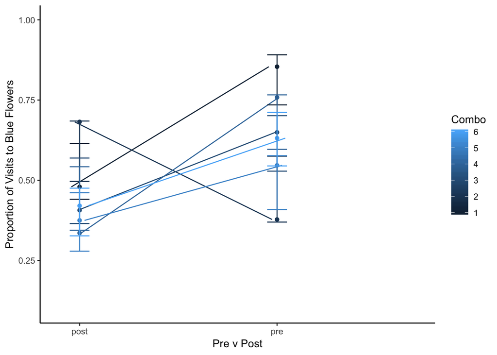

```r
#selecting the upper and lower bounds from the conf int table to add to RewardsPerTreatment
RpTUpLow=select(RpTconfint, lower, upper )
RewardsPerTreatment2=bind_cols(RewardsPerTreatment2,RpTUpLow)
index = which(is.na(RewardsPerTreatment2$Combo))
RewardsPerTreatment2 = RewardsPerTreatment2[-index,]

#plot 2- berry's aesthetic

pd <- position_dodge(width = 0.1)

plot2 <- ggplot(RewardsPerTreatment2, aes(color = Combo, y = AvgBluePreference, x = pre.post))
plot2 <- plot2 + geom_point(position=pd) + geom_line(aes(group = Combo), position=pd)
plot2 = plot2 + labs(x="Pre v Post", y="Proportion of Visits to Blue Flowers")
plot2= plot2 + theme_classic() + geom_errorbar(aes(ymin=lower, ymax=upper, width=.1), position=pd) + coord_cartesian(xlim = c(1.4,2.2), ylim = c(0.1,1.0))


plot2
```

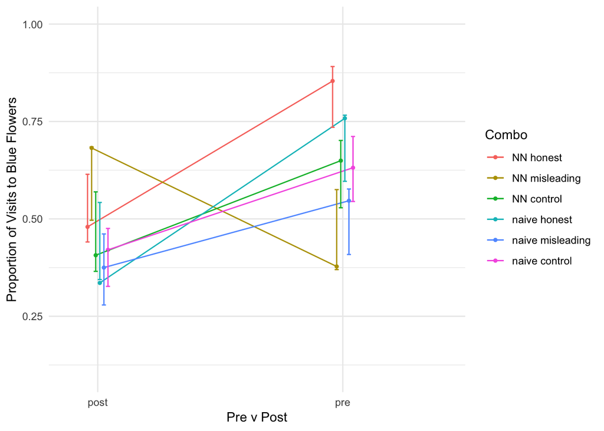

```r
#offsetting the error bars example from stack exchange
#pd <- position_dodge(width = 0.4)

#ggplot(YearlyDensity, aes(x = Year, y = mean, colour = Station, group = Station)) +
#  geom_errorbar(aes(ymin = mean-se, ymax = mean+se),
#                colour = "black", width = 0.2, position = pd) +
#  geom_line(size = .8, position = pd) +
#  geom_point(size = 4, shape = 18, position = pd) +

#mdf$variable <- as.numeric(as.character(mdf$variable))
RewardsPerTreatment2$Combo <-as.character(as.numeric(RewardsPerTreatment2$Combo))

pd <- position_dodge(width = 0.1)

plot3 <- ggplot(RewardsPerTreatment2, aes(group=Combo, color = Combo, y = AvgBluePreference, x = pre.post)) + geom_point( position=pd,size=1) + geom_line(aes(group = Combo), position=pd) + labs(x="Pre v Post", y="Proportion of Visits to Blue Flowers") + theme_minimal() + geom_errorbar(aes(ymin=lower, ymax=upper, width=.1), position=pd) + coord_cartesian(xlim = c(1.4,1.9), ylim = c(0.1,1.0))+ scale_color_hue(labels=c("NN honest", "NN misleading", "NN control", "naive honest", "naive misleading", "naive control"))



#scale_color_brewer(palette ="Set1" ) + scale_fill_discrete(name="Treatment", labels=c("NN honest", "NN misleading", "NN control", "naive honest", "naive misleading", "naive control"))

plot3
```